# Recommendation System

Akkash Kothapalli

## What is a Recommender System?

Recommender systems are software tools that predicts which user might like which item or viceverse.

Best examples are Netflix , Amazon, Facebook, Google etc.

- Bcoz nearly 35% of the revenue generated by Amazon are by Recommendation
- 2/3 Movies that are watch recommended movies.

Recommendation drives revenue for the companies. The best example is Banking.

#### Recommendations are used in

```
News
Tourism
Music
E-Commerce
Movies
Finance
Job Search
```

## Types of Recommender Systems

1. Traditional
2. Novel

#### Traditional

```
Popularity / Trending
Collaborative Filtering
Content Based
Knowledge Based
Association Rules
```

##### Collaborative Filtering

This is one of the most common and traditional algorithm. It is of 2 types

```
1. User Based CF
2. Item based CF
```

We will be creating the basic collaborative filtering from scratch. Later we will be creating using recommenderlab package.

```r
library(recommenderlab)
library(caret)
data("MovieLense")
```

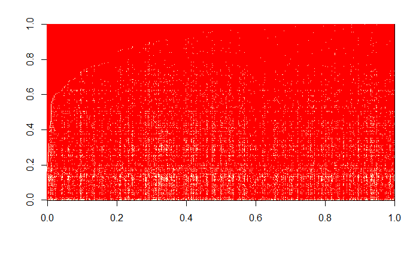

```r
movie.m <- as.data.frame(as.matrix(MovieLense@data))
#View(movie.m)
movie.m[movie.m > 0] <- 1
image(as.matrix(movie.m))
```

```r
head(movie.m)
```

|  | Toy Story (1995) | GoldenEye (1995) | Four Rooms (1995) | Get Shorty (1995) | Copycat (1995) | Shanghai Triad (Yao a yao yao dao waipo qiao) (1995) | Twelve Monkeys (1995) | Babe (1995) | Dead Man Walking (1995) | Richard III (1995) | Seven (Se7en) (1995) | Usual Suspects, The (1995) | Mighty Aphrodite (1995) | Postino, Il (1994) | Mr. Holland's Opus (1995) | French Twist (Gazon maudit) (1995) | From Dusk Till Dawn (1996) | White Balloon, The (1995) | Antonia's Line (1995) | Angels and Insects (1995) | Muppet Treasure Island (1996) | Braveheart (1995) | Taxi Driver (1976) | Rumble in the Bronx (1995) | Birdcage, The (1996) | Brothers McMullen, The (1995) | Bad Boys (1995) | Apollo 13 (1995) | Batman Forever (1995) | … |
| --- | --- | --- | --- | --- | --- | --- | --- | --- | --- | --- | --- | --- | --- | --- | --- | --- | --- | --- | --- | --- | --- | --- | --- | --- | --- | --- | --- | --- | --- | --- |
| 1 | 1 | 1 | 1 | 1 | 1 | 1 | 1 | 1 | 1 | 1 | 1 | 1 | 1 | 1 | 1 | 1 | 1 | 1 | 1 | 1 | 1 | 1 | 1 | 1 | 1 | 1 | 1 | 1 | 1 | … |
| 2 | 1 | 0 | 0 | 0 | 0 | 0 | 0 | 0 | 0 | 1 | 0 | 0 | 1 | 1 | 0 | 0 | 0 | 0 | 1 | 0 | 0 | 0 | 0 | 0 | 1 | 0 | 0 | 0 | 0 | … |
| 3 | 0 | 0 | 0 | 0 | 0 | 0 | 0 | 0 | 0 | 0 | 0 | 0 | 0 | 0 | 0 | 0 | 0 | 0 | 0 | 0 | 0 | 0 | 0 | 0 | 0 | 0 | 0 | 0 | 0 | … |
| 4 | 0 | 0 | 0 | 0 | 0 | 0 | 0 | 0 | 0 | 0 | 1 | 0 | 0 | 0 | 0 | 0 | 0 | 0 | 0 | 0 | 0 | 0 | 0 | 0 | 0 | 0 | 0 | 0 | 0 | … |
| 5 | 1 | 1 | 0 | 0 | 0 | 0 | 0 | 0 | 0 | 0 | 0 | 0 | 0 | 0 | 0 | 0 | 1 | 0 | 0 | 0 | 1 | 0 | 0 | 1 | 1 | 0 | 0 | 0 | 1 | … |
| 6 | 1 | 0 | 0 | 0 | 0 | 0 | 1 | 1 | 1 | 0 | 0 | 1 | 1 | 1 | 1 | 0 | 0 | 0 | 1 | 0 | 1 | 1 | 1 | 0 | 0 | 0 | 0 | 1 | 0 | … |

Now we hae created the dataset. The basic idea behind a collaborative filtering is that its find the similarities between User-User or Item-Item. Here in this demo we will be using the User-User CF.

But how to find similarity between User-user or Item-Item

There are different types of similairty formulas that can be used the most common are

```
1. Cosine
2. Pearson Correlation
3. Jaccard
```

```r
distance <- as.matrix(dist(movie.m,method = 'euclidean'))
#View(distance)

correlation <- as.matrix(dist(movie.m,method = 'correlation'))
#View(correlation)

jaccard <- as.matrix(dist(movie.m,method = 'jaccard'))
#View(jaccard)

cosine <- as.matrix(dist(movie.m,method = 'cosine'))
#View(cosine)
```

Now lets find the nearest neighbours

```r
k.nearest.neighbors <- function(i, recommender, k = 5)
{
  ordered.neighbors <- order(recommender[i, ])
  # This just gives us the list of points that are
  # closest to row i in descending order.

  # The first entry is always 0 (the closest point is the point itself) so
  # let's ignore that entry and return points 2:(k+1) instead of 1:k
  return(ordered.neighbors[2:(k + 1)])
}
```

```r
cat('euclidian..')
```

```
euclidian..
```

```r
k.nearest.neighbors(25,distance,15) #eculidian
```

```
 [1] 419 895 153 512 700  53  93 124 202 247 513 800 941  55 310
```

```r
cat('correlation..')
```

```
correlation..
```

```r
k.nearest.neighbors(25,correlation,15) #correlation
```

```
 [1] 519 489 695 863 531 451 587 813 355 511 688 801 808 155 241
```

```r
cat('jaccard..')
```

```
jaccard..
```

```r
k.nearest.neighbors(25,jaccard,15) #jaccard
```

```
 [1] 913 748 148 899 882  97 786 263 890 213  14 312 298 848  23
```

```r
cat('cosine..')
```

```
cosine..
```

```r
k.nearest.neighbors(25,cosine,15) #cosine
```

```
 [1] 913 313 716 748 312 148 899 882 650 892   6 786 666  97 862
```

Now lets find the probability of the user watching a particular movie

```r
seen.probability <- function(user, movie, recommender, distances, k = 25)
{
  # Find the kNN closest movies to this movie in question.

  neighbors <- k.nearest.neighbors(which(row.names(movie.m) == user), distances, k)



  # Now that we know the other movies that have been seen with this one, return
  # the mean of how many of those movies this user could see.
  return(mean(movie.m[neighbors, movie]))
}
```

```r
seen.probability(5,'Four Rooms (1995)',movie.m,distance)
```

```
[1] 0
```

```r
seen.probability(5,'GoldenEye (1995)',movie.m,distance)
```

```
[1] 0.08
```

```r
seen.probability(5,'Toy Story (1995)',movie.m,distance)
```

```
[1] 0.4
```

```r
most.prob.movies <- function(user,recommender,distance,k=25){
  probabilities <- rep(0,ncol(recommender))
  for(i in 1:ncol(recommender)){
    if(recommender[user,i]==1){
      next
    }
    probabilities[i] <- seen.probability(user,colnames(recommender)[i],recommender,distance,k)
  }
  return(order(probabilities,decreasing = T))
}
```

```r
user_movies <- movie.m[25,]
viewed_movies <- colnames(user_movies[,user_movies==1])
viewed_movies
```

```
 [1] "Toy Story (1995)"
 [2] "Twelve Monkeys (1995)"
 [3] "Babe (1995)"
 [4] "Mighty Aphrodite (1995)"
 [5] "Taxi Driver (1976)"
 [6] "Birdcage, The (1996)"
 [7] "Star Wars (1977)"
 [8] "Fugitive, The (1993)"
 [9] "Jurassic Park (1993)"
[10] "Remains of the Day, The (1993)"
[11] "Silence of the Lambs, The (1991)"
[12] "Wallace & Gromit: The Best of Aardman Animation (1996)"
[13] "Cold Comfort Farm (1995)"
[14] "Independence Day (ID4) (1996)"
[15] "Phenomenon (1996)"
```

[output cut: 63 more lines]

```r
cat('\n Movies to recommend \n \n')
```

```
 Movies to recommend
```

```r
listing <- most.prob.movies(25,movie.m,distance)
colnames(movie.m)[listing[1:10]]
```

```
 [1] "Mr. Holland's Opus (1995)"         "Twister (1996)"                    "Empire Strikes Back, The (1980)"
 [4] "Rock, The (1996)"                  "Liar Liar (1997)"                  "Pulp Fiction (1994)"
 [7] "Shawshank Redemption, The (1994)"  "Terminator 2: Judgment Day (1991)" "Fargo (1996)"
[10] "Die Hard (1988)"
```

```r
user_movies <- movie.m[65,]
viewed_movies <- colnames(user_movies[,user_movies==1])
viewed_movies
```

```
 [1] "Toy Story (1995)"                          "Twelve Monkeys (1995)"
 [3] "Dead Man Walking (1995)"                   "Mr. Holland's Opus (1995)"
 [5] "Birdcage, The (1996)"                      "Apollo 13 (1995)"
 [7] "Ed Wood (1994)"                            "Hoop Dreams (1994)"
 [9] "Star Wars (1977)"                          "Pulp Fiction (1994)"
[11] "Santa Clause, The (1994)"                  "Shawshank Redemption, The (1994)"
[13] "What's Eating Gilbert Grape (1993)"        "While You Were Sleeping (1995)"
[15] "Forrest Gump (1994)"                       "Four Weddings and a Funeral (1994)"
[17] "Maverick (1994)"                           "Firm, The (1993)"
[19] "Searching for Bobby Fischer (1993)"        "Sleepless in Seattle (1993)"
[21] "Dances with Wolves (1990)"                 "Silence of the Lambs, The (1991)"
[23] "Fargo (1996)"                              "Truth About Cats & Dogs, The (1996)"
[25] "Independence Day (ID4) (1996)"             "Phenomenon (1996)"
[27] "2001: A Space Odyssey (1968)"              "Monty Python and the Holy Grail (1974)"
[29] "Princess Bride, The (1987)"                "12 Angry Men (1957)"
```

[output cut: 25 more lines]

```r
cat('\n Movies to recommend \n \n')
```

```
 Movies to recommend
```

```r
listing <- most.prob.movies(65,movie.m,distance)
colnames(movie.m)[listing[1:10]]
```

```
 [1] "English Patient, The (1996)" "Return of the Jedi (1983)"   "Godfather, The (1972)"
 [4] "Full Monty, The (1997)"      "Scream (1996)"               "Air Force One (1997)"
 [7] "Titanic (1997)"              "Big Night (1996)"            "Back to the Future (1985)"
[10] "Good Will Hunting (1997)"
```